# all_data

Autogenerated data summary from dataMaid

2024-06-20 13:10:31.905732

# Data report overview

The dataset examined has the following dimensions:

| Feature | Result |
| --- | --- |
| Number of observations | 3221 |
| Number of variables | 75 |

### Checks performed

The following variable checks were performed, depending on the data type of each variable:

|  | character | factor | labelled | haven labelled | numeric | integer | logical | Date |
| --- | --- | --- | --- | --- | --- | --- | --- | --- |
| Identify miscoded missing values | × | × | × | × | × | × |  | × |
| Identify prefixed and suffixed whitespace | × | × | × | × |  |  |  |  |
| Identify levels with < 6 obs. | × | × | × | × |  |  |  |  |
| Identify case issues | × | × | × | × |  |  |  |  |
| Identify misclassified numeric or integer variables | × | × | × | × |  |  |  |  |
| Identify outliers |  |  |  |  | × | × |  | × |

Please note that all numerical values in the following have been rounded to 2 decimals.

# Summary table

|  | Variable class | # unique values | Missing observations | Any problems? |
| --- | --- | --- | --- | --- |
| GEOID | character | 3221 | 0.00 % | × |
| NAME | character | 3221 | 0.00 % | × |
| county | character | 1956 | 0.00 % | × |
| state | character | 52 | 0.00 % | × |
| sq_mi | numeric | 3221 | 0.00 % | × |
| population | numeric | 3143 | 0.00 % | × |
| pop_density | numeric | 3221 | 0.00 % | × |
| pct_minority | numeric | 3217 | 0.00 % |  |
| pct_black | numeric | 3132 | 0.00 % |  |
| pct_latin | numeric | 3207 | 0.00 % | × |
| pct_under_18 | numeric | 3220 | 0.00 % | × |
| pct_65_over | numeric | 3219 | 0.00 % | × |
| pct_poverty | numeric | 3141 | 2.42 % | × |
| pct_income100more | numeric | 3218 | 0.00 % | × |
| pct_snap | numeric | 3209 | 0.03 % | × |
| pct_not_in_labor_force | numeric | 3217 | 0.00 % | × |
| pct_no_cars | numeric | 3200 | 0.00 % | × |
| pct_no_bach | numeric | 3143 | 2.42 % | × |
| pct_travel_under_hr | numeric | 3209 | 0.00 % | × |
| pct_stayed_1yr | numeric | 3142 | 2.42 % | × |
| pct_homevalue250more | numeric | 3215 | 0.03 % | × |
| pct_homeowner | numeric | 3212 | 0.00 % | × |
| med_income | numeric | 3105 | 0.03 % | × |
| tract | character | 1841 | 2.42 % | × |
| ACCESS2 | numeric | 322 | 2.42 % | × |
| ARTHRITIS | numeric | 254 | 2.42 % | × |
| BINGE | numeric | 155 | 2.42 % | × |
| BPHIGH | numeric | 304 | 3.14 % | × |
| BPMED | numeric | 212 | 3.14 % | × |
| CANCER | numeric | 78 | 2.42 % | × |
| CASTHMA | numeric | 63 | 2.42 % | × |
| CERVICAL | numeric | 153 | 2.42 % | × |
| CHD | numeric | 100 | 2.42 % | × |
| CHECKUP | numeric | 218 | 2.42 % | × |
| CHOLSCREEN | numeric | 163 | 3.14 % | × |
| COLON_SCREEN | numeric | 253 | 2.42 % | × |
| COPD | numeric | 136 | 2.42 % | × |
| COREM | numeric | 290 | 2.42 % | × |
| COREW | numeric | 260 | 2.42 % | × |
| CSMOKING | numeric | 237 | 2.42 % | × |
| DENTAL | numeric | 366 | 2.42 % | × |
| DEPRESSION | numeric | 168 | 2.42 % | × |
| DIABETES | numeric | 159 | 2.42 % | × |
| GHLTH | numeric | 250 | 2.42 % | × |
| HIGHCHOL | numeric | 197 | 3.14 % | × |
| KIDNEY | numeric | 45 | 2.42 % | × |
| LPA | numeric | 287 | 2.42 % | × |
| MAMMOUSE | numeric | 223 | 2.42 % | × |
| MHLTH | numeric | 118 | 2.42 % | × |
| OBESITY | numeric | 281 | 2.42 % | × |
| PHLTH | numeric | 141 | 2.42 % | × |
| SLEEP | numeric | 200 | 2.42 % | × |
| STROKE | numeric | 58 | 2.42 % | × |
| TEETHLOST | numeric | 212 | 2.42 % | × |
| ncrural | numeric | 3 | 0.00 % |  |
| ncrural_Desc | character | 3 | 0.00 % |  |
| ncrural_fact | factor | 3 | 0.00 % |  |
| RUCC_2013 | numeric | 10 | 0.12 % | × |
| RUCC_Desc | factor | 10 | 0.12 % |  |
| RUCC_fact | factor | 10 | 0.12 % | × |
| UIC_2013 | numeric | 13 | 0.12 % |  |
| UIC_Desc | factor | 13 | 0.12 % |  |
| UIC_fact | factor | 13 | 0.12 % | × |
| PCT_LACCESS_POP15 | numeric | 3113 | 3.14 % | × |
| GROCPTH16 | numeric | 3022 | 2.55 % | × |
| SUPERCPTH16 | numeric | 1782 | 2.55 % | × |
| CONVSPTH16 | numeric | 3073 | 2.55 % | × |
| SNAPSPTH17 | numeric | 3104 | 3.29 % | × |
| WICSPTH16 | numeric | 2938 | 7.45 % | × |
| FFRPTH16 | numeric | 2961 | 2.55 % | × |
| FSRPTH16 | numeric | 3050 | 2.55 % | × |
| geometry | sfc_MULTIPOLYGON | 3221 | 0.00 % | × |
| metro_class | numeric | 4 | 0.12 % |  |
| metro_Desc | character | 4 | 0.12 % |  |
| metro_fact | factor | 4 | 0.12 % |  |

# Variable list

## GEOID

- The variable is a key (distinct values for each observation).

## NAME

- The variable is a key (distinct values for each observation).

## county

| Feature | Result |
| --- | --- |
| Variable type | character |
| Number of missing obs. | 0 (0 %) |
| Number of unique values | 1956 |
| Mode | “Washington County” |

[figure not shown]

- Note that the following levels have at most five observations: "Abbeville County", "Acadia Parish", "Accomack County", "Ada County", "Adair County", …, "Yukon-Koyukuk Census Area", "Yuma County", "Zapata County", "Zavala County", "Ziebach County" (1874 values omitted).

## state

| Feature | Result |
| --- | --- |
| Variable type | character |
| Number of missing obs. | 0 (0 %) |
| Number of unique values | 52 |
| Mode | “Texas” |

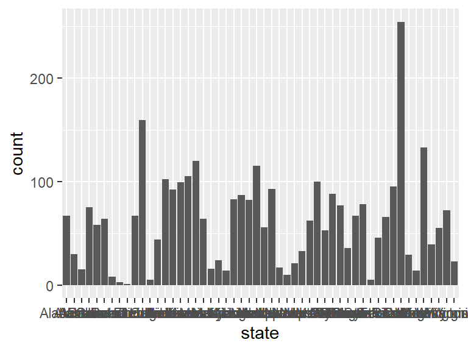

- Note that the following levels have at most five observations: "Delaware", "District of Columbia", "Hawaii", "Rhode Island".

## sq_mi

| Feature | Result |
| --- | --- |
| Variable type | numeric |
| Number of missing obs. | 0 (0 %) |
| Number of unique values | 3221 |
| Median | 619.32 |
| 1st and 3rd quartiles | 428.83; 934.69 |
| Min. and max. | 2.04; 146896.6 |

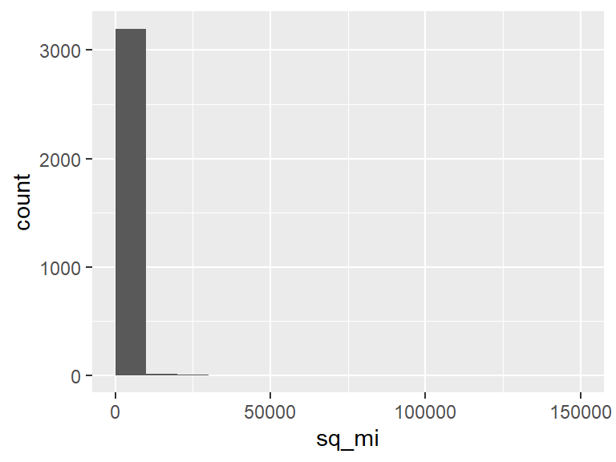

- Note that the following possible outlier values were detected: "2.04", "2.52", "3.03", "5", "5.66", …, "26318.79", "36523.01", "42202.78", "89551.71", "146896.6" (422 values omitted).

## population

| Feature | Result |
| --- | --- |
| Variable type | numeric |
| Number of missing obs. | 0 (0 %) |
| Number of unique values | 3143 |
| Median | 25916 |
| 1st and 3rd quartiles | 11032; 67298 |
| Min. and max. | 48; 10019635 |

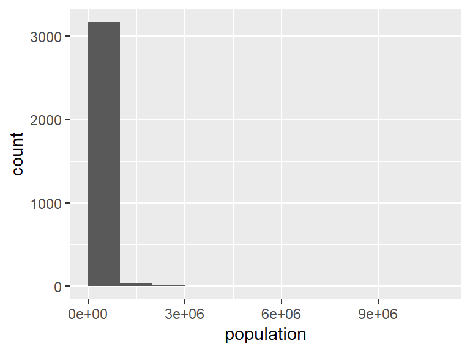

- Note that the following possible outlier values were detected: "48", "83", "169", "229", "346", …, "3296317", "4367186", "4697957", "5265398", "10019635" (244 values omitted).

## pop_density

| Feature | Result |
| --- | --- |
| Variable type | numeric |
| Number of missing obs. | 0 (0 %) |
| Number of unique values | 3221 |
| Median | 45.09 |
| 1st and 3rd quartiles | 16.62; 131.54 |
| Min. and max. | 0.04; 52075.08 |

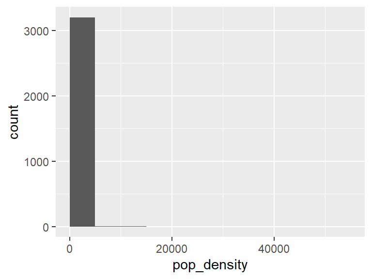

- Note that the following possible outlier values were detected: "0.04", "0.04", "0.07", "0.11", "0.11", …, "18250.23", "19137.23", "30445.14", "32884.33", "52075.08" (170 values omitted).

## pct_minority

| Feature | Result |
| --- | --- |
| Variable type | numeric |
| Number of missing obs. | 0 (0 %) |
| Number of unique values | 3217 |
| Median | 18.32 |
| 1st and 3rd quartiles | 8.64; 38.31 |
| Min. and max. | 0; 100 |

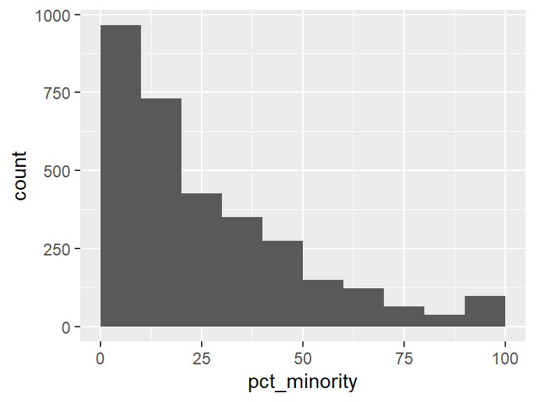

## pct_black

| Feature | Result |
| --- | --- |
| Variable type | numeric |
| Number of missing obs. | 0 (0 %) |
| Number of unique values | 3132 |
| Median | 2.3 |
| 1st and 3rd quartiles | 0.7; 10.07 |
| Min. and max. | 0; 87.12 |

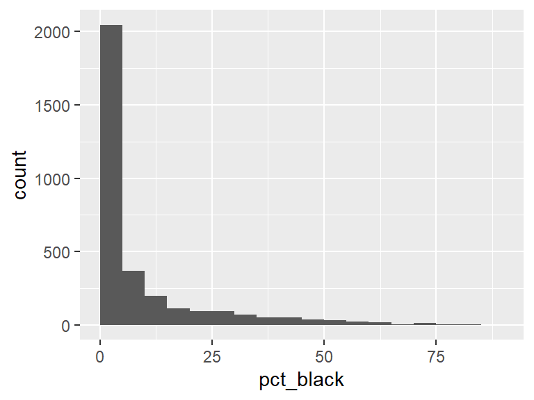

## pct_latin

| Feature | Result |
| --- | --- |
| Variable type | numeric |
| Number of missing obs. | 0 (0 %) |
| Number of unique values | 3207 |
| Median | 4.67 |
| 1st and 3rd quartiles | 2.46; 11.01 |
| Min. and max. | 0; 100 |

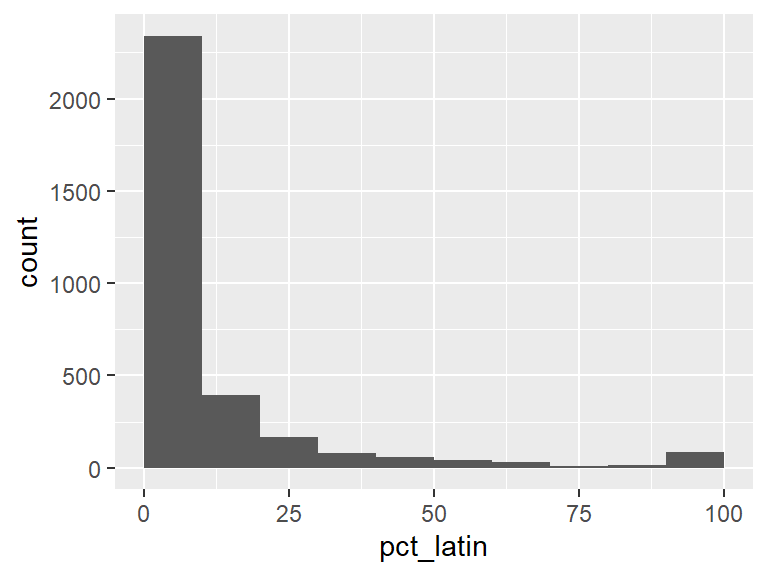

- Note that the following possible outlier values were detected: "0", "0.01", "0.02", "0.02", "0.03", …, "99.88", "99.89", "99.93", "99.96", "100" (266 values omitted).

## pct_under_18

| Feature | Result |
| --- | --- |
| Variable type | numeric |
| Number of missing obs. | 0 (0 %) |
| Number of unique values | 3220 |
| Median | 22.17 |
| 1st and 3rd quartiles | 20; 24.02 |
| Min. and max. | 2.08; 41.37 |

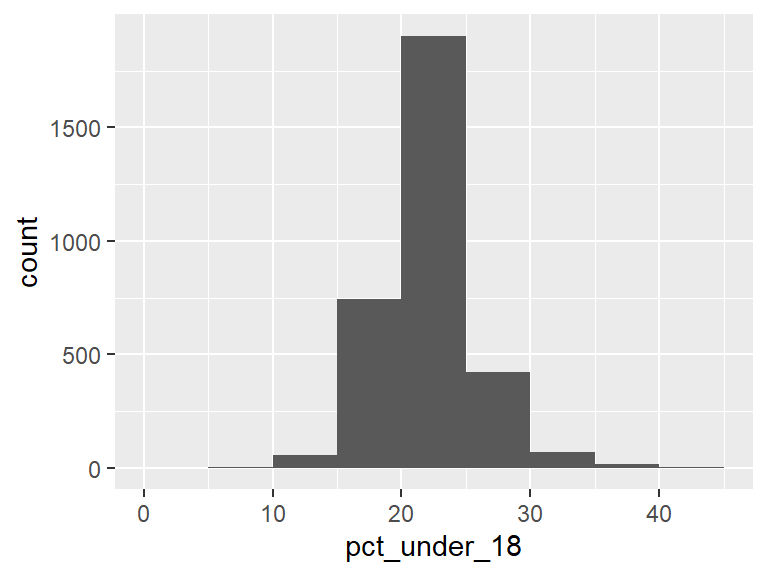

- Note that the following possible outlier values were detected: "2.08", "7.17", "7.41", "8.22", "8.87", …, "38.71", "39.05", "40.75", "40.83", "41.37" (140 values omitted).

## pct_65_over

| Feature | Result |
| --- | --- |
| Variable type | numeric |
| Number of missing obs. | 0 (0 %) |
| Number of unique values | 3219 |
| Median | 18.85 |
| 1st and 3rd quartiles | 16.23; 21.71 |
| Min. and max. | 3.07; 57.63 |

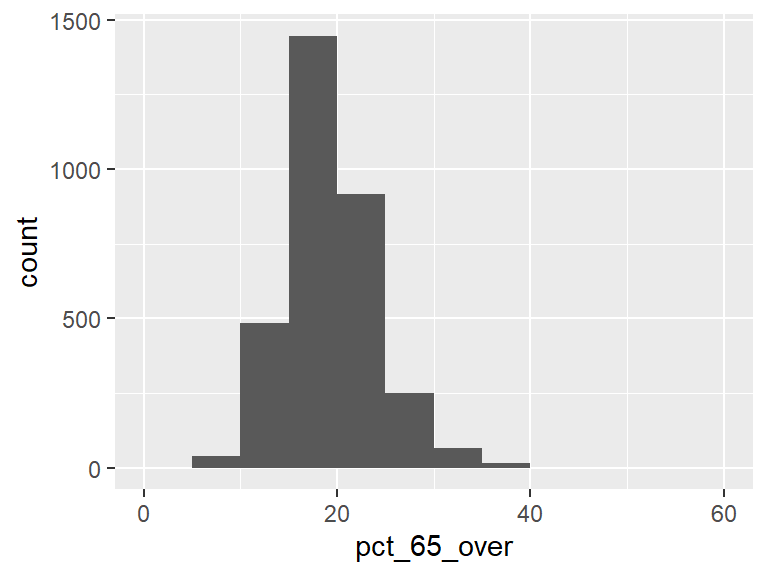

- Note that the following possible outlier values were detected: "3.07", "5.87", "6.88", "6.95", "7.05", …, "38.81", "39.64", "39.85", "42.28", "57.63" (80 values omitted).

## pct_poverty

| Feature | Result |
| --- | --- |
| Variable type | numeric |
| Number of missing obs. | 78 (2.42 %) |
| Number of unique values | 3140 |
| Median | 13.45 |
| 1st and 3rd quartiles | 10.15; 17.6 |
| Min. and max. | 1.2; 59.02 |

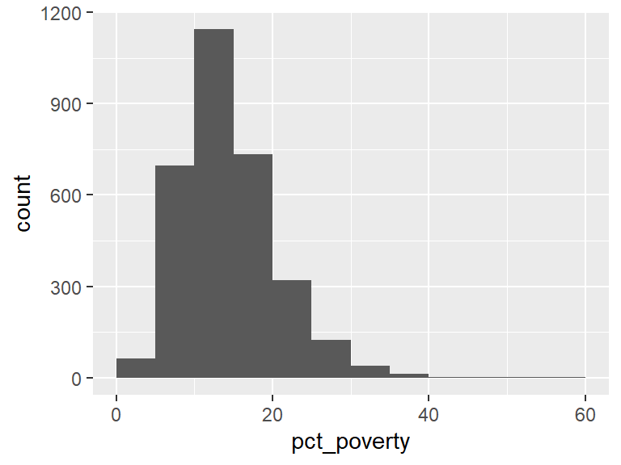

- Note that the following possible outlier values were detected: "1.2", "1.78", "1.8", "2.36", "2.48", …, "46.49", "47.26", "49.97", "50.5", "59.02" (28 values omitted).

## pct_income100more

| Feature | Result |
| --- | --- |
| Variable type | numeric |
| Number of missing obs. | 0 (0 %) |
| Number of unique values | 3218 |
| Median | 22.52 |
| 1st and 3rd quartiles | 17.42; 28.36 |
| Min. and max. | 0; 70.89 |

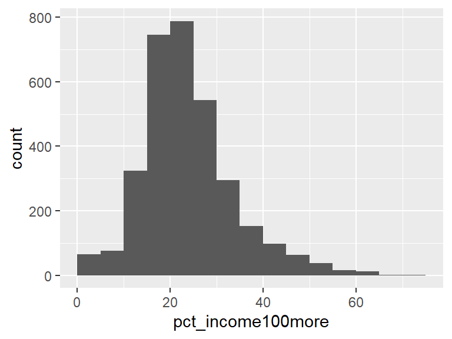

- Note that the following possible outlier values were detected: "0", "0.09", "0.1", "0.19", "0.32", …, "63.11", "63.52", "63.75", "68.85", "70.89" (127 values omitted).

## pct_snap

| Feature | Result |
| --- | --- |
| Variable type | numeric |
| Number of missing obs. | 1 (0.03 %) |
| Number of unique values | 3209 |
| Median | 24.98 |
| 1st and 3rd quartiles | 17.33; 33.54 |
| Min. and max. | 0; 80.35 |

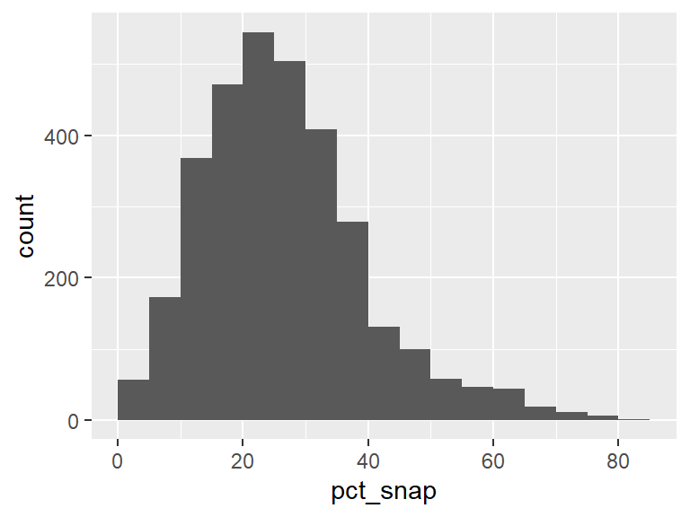

- The following suspected missing value codes enter as regular values: "NaN".
- Note that the following possible outlier values were detected: "0", "0.21", "65.7", "66.31", "66.61", …, "77.44", "77.57", "77.68", "78.4", "80.35" (25 values omitted).

## pct_not_in_labor_force

| Feature | Result |
| --- | --- |
| Variable type | numeric |
| Number of missing obs. | 0 (0 %) |
| Number of unique values | 3217 |
| Median | 41.07 |
| 1st and 3rd quartiles | 36.13; 47.13 |
| Min. and max. | 16.82; 80.7 |

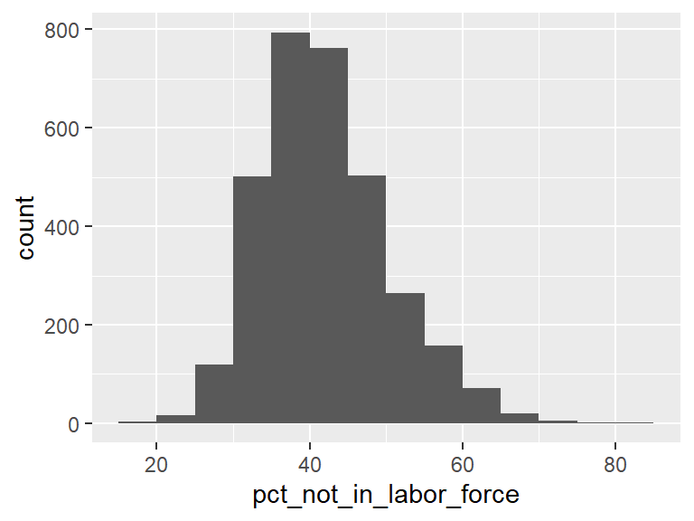

- Note that the following possible outlier values were detected: "16.82", "18.61", "19.97", "20.34", "21.41", …, "73.94", "74.48", "75.04", "76.05", "80.7" (22 values omitted).

## pct_no_cars

| Feature | Result |
| --- | --- |
| Variable type | numeric |
| Number of missing obs. | 0 (0 %) |
| Number of unique values | 3200 |
| Median | 5.43 |
| 1st and 3rd quartiles | 3.99; 7.5 |
| Min. and max. | 0; 88.21 |

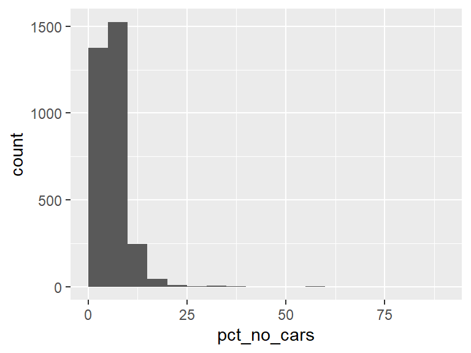

- Note that the following possible outlier values were detected: "0", "0.25", "0.42", "0.44", "0.45", …, "59.64", "60.13", "66.06", "77.35", "88.21" (115 values omitted).

## pct_no_bach

| Feature | Result |
| --- | --- |
| Variable type | numeric |
| Number of missing obs. | 78 (2.42 %) |
| Number of unique values | 3142 |
| Median | 79.48 |
| 1st and 3rd quartiles | 72.7; 83.87 |
| Min. and max. | 21.3; 100 |

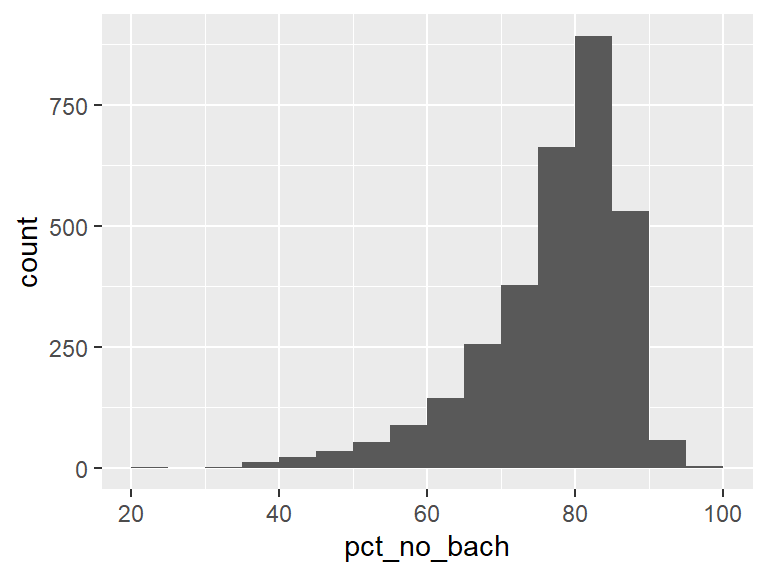

- Note that the following possible outlier values were detected: "21.3", "23.7", "31.48", "34.82", "89.54", …, "93.62", "95.53", "96.12", "97.08", "100" (82 values omitted).

## pct_travel_under_hr

| Feature | Result |
| --- | --- |
| Variable type | numeric |
| Number of missing obs. | 0 (0 %) |
| Number of unique values | 3209 |
| Median | 93.01 |
| 1st and 3rd quartiles | 89.29; 95.34 |
| Min. and max. | 60.48; 100 |

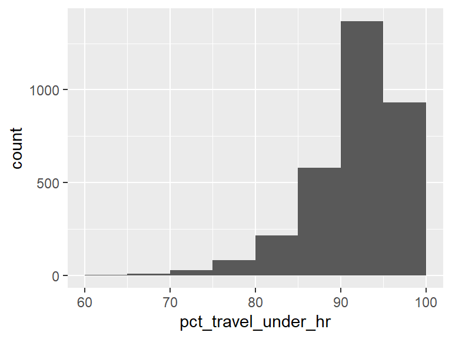

- Note that the following possible outlier values were detected: "60.48", "63.04", "63.16", "64.96", "65.19", …, "99.82", "99.82", "99.89", "99.94", "100" (45 values omitted).

## pct_stayed_1yr

| Feature | Result |
| --- | --- |
| Variable type | numeric |
| Number of missing obs. | 78 (2.42 %) |
| Number of unique values | 3141 |
| Median | 88.31 |
| 1st and 3rd quartiles | 85.8; 90.49 |
| Min. and max. | 62.94; 100 |

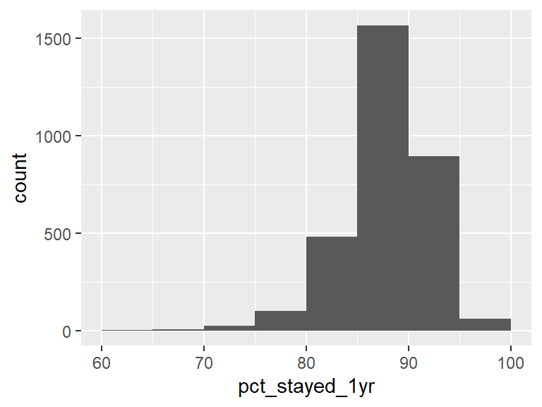

- Note that the following possible outlier values were detected: "62.94", "63.53", "66.72", "66.73", "67.41", …, "97.51", "97.89", "98.44", "99.63", "100" (83 values omitted).

## pct_homevalue250more

| Feature | Result |
| --- | --- |
| Variable type | numeric |
| Number of missing obs. | 1 (0.03 %) |
| Number of unique values | 3215 |
| Median | 19.91 |
| 1st and 3rd quartiles | 12.78; 34.02 |
| Min. and max. | 0; 97.43 |

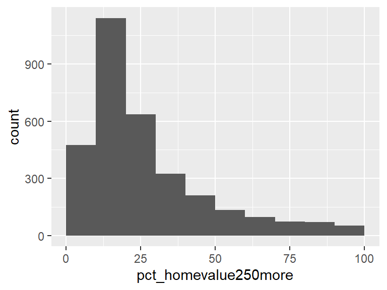

- The following suspected missing value codes enter as regular values: "NaN".
- Note that the following possible outlier values were detected: "0", "0.4", "0.79", "0.97", "1.02", …, "5.74", "5.79", "5.84", "5.91", "5.92" (142 values omitted).

## pct_homeowner

| Feature | Result |
| --- | --- |
| Variable type | numeric |
| Number of missing obs. | 0 (0 %) |
| Number of unique values | 3212 |
| Median | 73.59 |
| 1st and 3rd quartiles | 68.2; 78.17 |
| Min. and max. | 0; 96.52 |

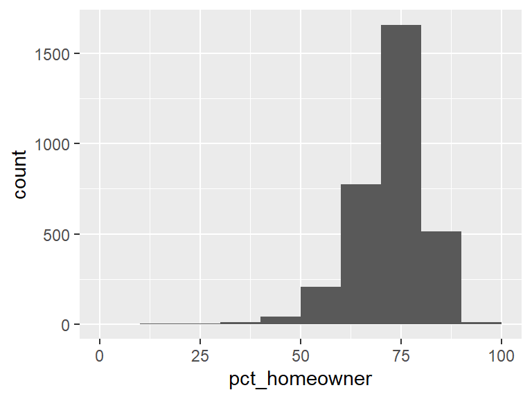

- Note that the following possible outlier values were detected: "0", "10.42", "19.84", "24.08", "24.65", …, "92.06", "92.51", "92.61", "95.07", "96.52" (61 values omitted).

## med_income

| Feature | Result |
| --- | --- |
| Variable type | numeric |
| Number of missing obs. | 1 (0.03 %) |
| Number of unique values | 3104 |
| Median | 55652 |
| 1st and 3rd quartiles | 47299.5; 64609.75 |
| Min. and max. | 12856; 156821 |

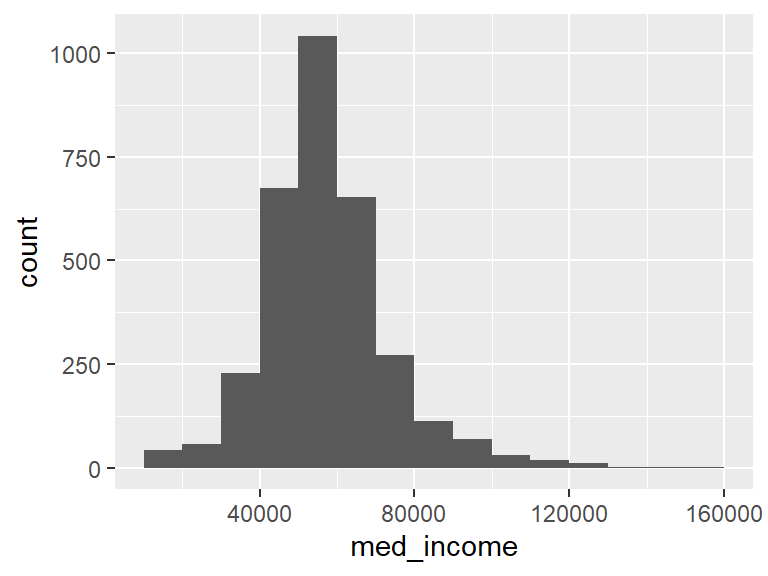

- Note that the following possible outlier values were detected: "12856", "14666", "14933", "14942", "15353", …, "133974", "136837", "140258", "155071", "156821" (157 values omitted).

## tract

| Feature | Result |
| --- | --- |
| Variable type | character |
| Number of missing obs. | 78 (2.42 %) |
| Number of unique values | 1840 |
| Mode | “Washington” |

[figure not shown]

- Note that the following levels have at most five observations: "Abbeville", "Acadia", "Accomack", "Ada", "Adair", …, "Yukon-Koyukuk", "Yuma", "Zapata", "Zavala", "Ziebach" (1756 values omitted).

## ACCESS2

| Feature | Result |
| --- | --- |
| Variable type | numeric |
| Number of missing obs. | 78 (2.42 %) |
| Number of unique values | 321 |
| Median | 14.4 |
| 1st and 3rd quartiles | 11.5; 18.8 |
| Min. and max. | 5.5; 53.4 |

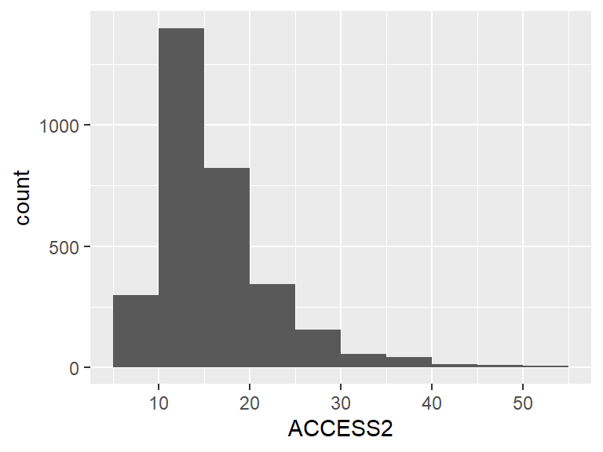

- Note that the following possible outlier values were detected: "5.5", "5.6", "5.7", "5.8", "6.1", …, "50.1", "50.4", "51.2", "51.3", "53.4" (21 values omitted).

## ARTHRITIS

| Feature | Result |
| --- | --- |
| Variable type | numeric |
| Number of missing obs. | 78 (2.42 %) |
| Number of unique values | 253 |
| Median | 29.3 |
| 1st and 3rd quartiles | 26.3; 32.3 |
| Min. and max. | 13.5; 45.5 |

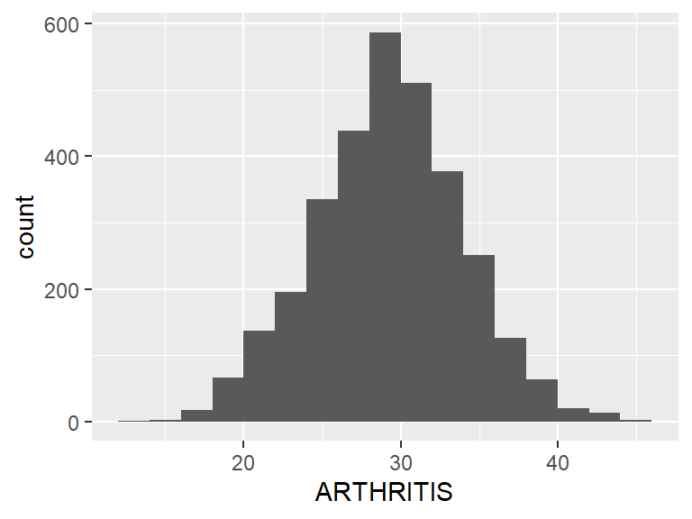

- Note that the following possible outlier values were detected: "13.5", "14.3", "16", "16.2", "16.5", …, "42.7", "42.9", "43.4", "44.5", "45.5" (14 values omitted).

## BINGE

| Feature | Result |
| --- | --- |
| Variable type | numeric |
| Number of missing obs. | 78 (2.42 %) |
| Number of unique values | 154 |
| Median | 15.5 |
| 1st and 3rd quartiles | 13.8; 17.4 |
| Min. and max. | 8.2; 25.6 |

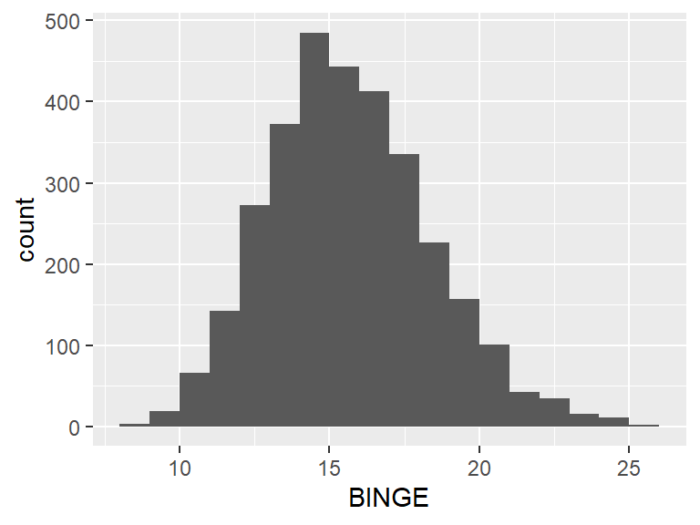

- Note that the following possible outlier values were detected: "8.2", "9", "9.2", "9.4", "9.5", …, "24.6", "24.7", "24.8", "25.2", "25.6" (5 values omitted).

## BPHIGH

| Feature | Result |
| --- | --- |
| Variable type | numeric |
| Number of missing obs. | 101 (3.14 %) |
| Number of unique values | 303 |
| Median | 36.9 |
| 1st and 3rd quartiles | 33.4; 40.8 |
| Min. and max. | 19.9; 58.7 |

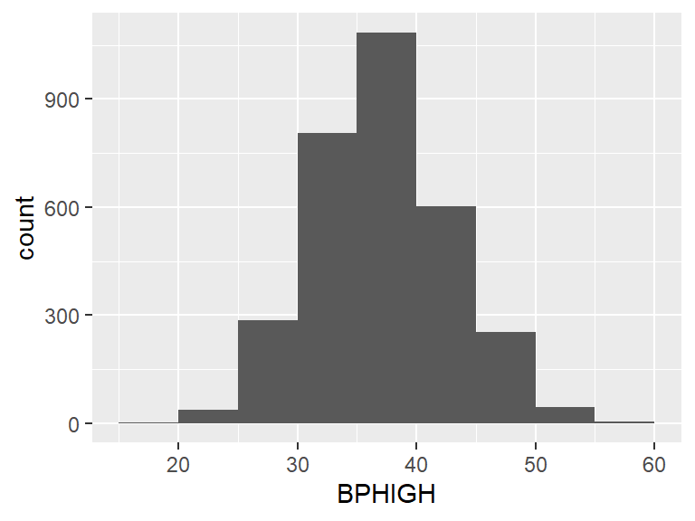

- Note that the following possible outlier values were detected: "19.9", "20", "20.4", "21.3", "22", …, "55", "55.4", "55.7", "55.8", "58.7" (24 values omitted).

## BPMED

| Feature | Result |
| --- | --- |
| Variable type | numeric |
| Number of missing obs. | 101 (3.14 %) |
| Number of unique values | 211 |
| Median | 78 |
| 1st and 3rd quartiles | 75.6; 79.9 |
| Min. and max. | 56.1; 85.8 |

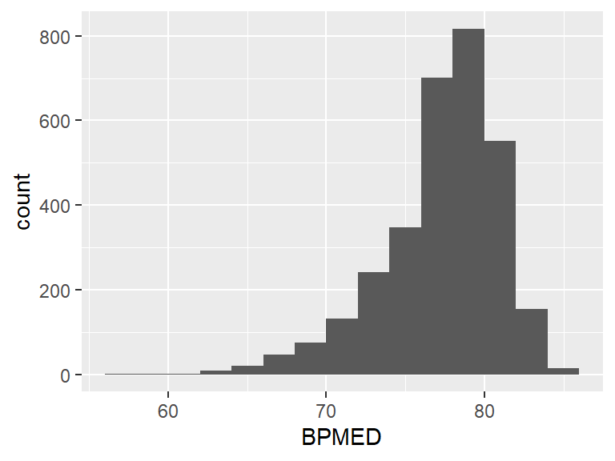

- Note that the following possible outlier values were detected: "56.1", "59.1", "59.9", "61.7", "61.9", …, "84.6", "84.9", "85.4", "85.6", "85.8" (25 values omitted).

## CANCER

| Feature | Result |
| --- | --- |
| Variable type | numeric |
| Number of missing obs. | 78 (2.42 %) |
| Number of unique values | 77 |
| Median | 7.6 |
| 1st and 3rd quartiles | 6.8; 8.3 |
| Min. and max. | 2.7; 13.6 |

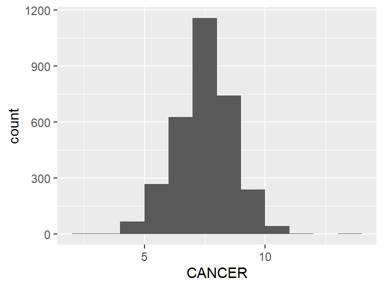

- Note that the following possible outlier values were detected: "2.7", "3.8", "3.9", "4", "4.1", …, "11", "11.1", "11.2", "11.3", "13.6" (8 values omitted).

## CASTHMA

| Feature | Result |
| --- | --- |
| Variable type | numeric |
| Number of missing obs. | 78 (2.42 %) |
| Number of unique values | 62 |
| Median | 9.9 |
| 1st and 3rd quartiles | 9.3; 10.5 |
| Min. and max. | 7.1; 14.3 |

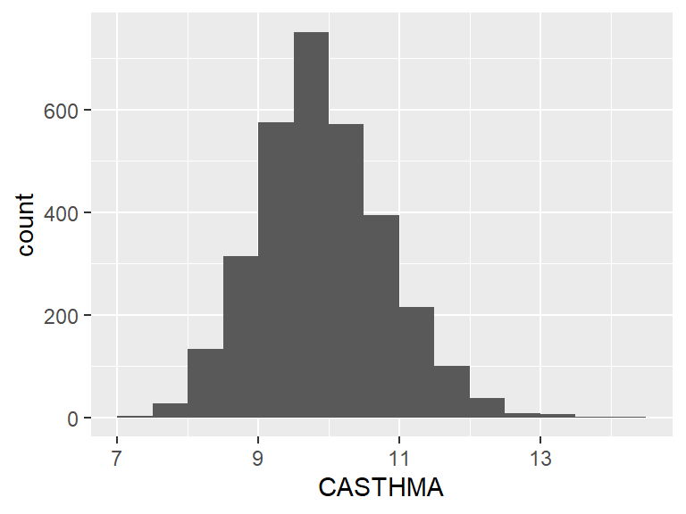

- Note that the following possible outlier values were detected: "7.1", "7.2", "7.4", "7.7", "7.8", …, "13.3", "13.4", "13.6", "14.2", "14.3" (4 values omitted).

## CERVICAL

| Feature | Result |
| --- | --- |
| Variable type | numeric |
| Number of missing obs. | 78 (2.42 %) |
| Number of unique values | 152 |
| Median | 81 |
| 1st and 3rd quartiles | 79.3; 82.5 |
| Min. and max. | 68.3; 87.6 |

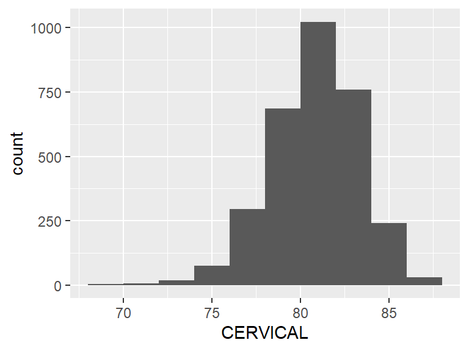

- Note that the following possible outlier values were detected: "68.3", "69.7", "70", "70.3", "71.3", …, "86.9", "87.1", "87.3", "87.4", "87.6" (18 values omitted).

## CHD

| Feature | Result |
| --- | --- |
| Variable type | numeric |
| Number of missing obs. | 78 (2.42 %) |
| Number of unique values | 99 |
| Median | 8.3 |
| 1st and 3rd quartiles | 7.1; 9.3 |
| Min. and max. | 3.5; 14.1 |

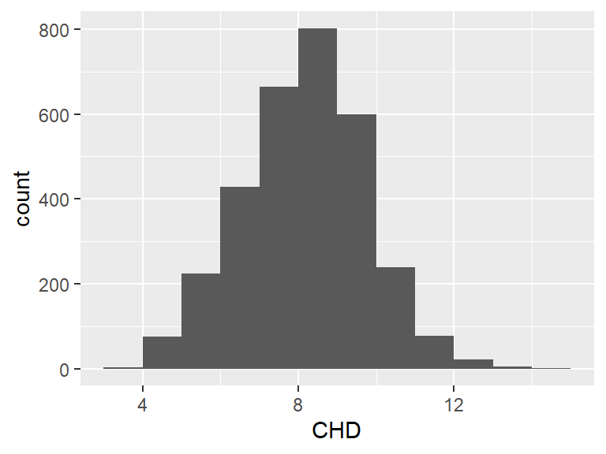

- Note that the following possible outlier values were detected: "11.9", "12", "12.1", "12.2", "12.3", …, "13.4", "13.6", "13.7", "13.9", "14.1" (7 values omitted).

## CHECKUP

| Feature | Result |
| --- | --- |
| Variable type | numeric |
| Number of missing obs. | 78 (2.42 %) |
| Number of unique values | 217 |
| Median | 76 |
| 1st and 3rd quartiles | 73.1; 78.1 |
| Min. and max. | 59; 84.6 |

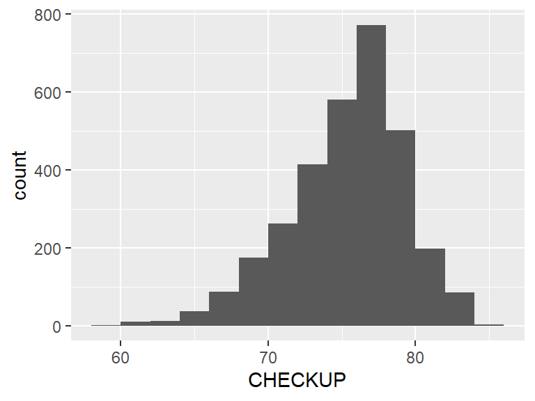

- Note that the following possible outlier values were detected: "59", "60.3", "60.4", "81.9", "82", …, "83.9", "84.2", "84.3", "84.4", "84.6" (18 values omitted).

## CHOLSCREEN

| Feature | Result |
| --- | --- |
| Variable type | numeric |
| Number of missing obs. | 101 (3.14 %) |
| Number of unique values | 162 |
| Median | 85.7 |
| 1st and 3rd quartiles | 84; 87.2 |
| Min. and max. | 70.1; 93.2 |

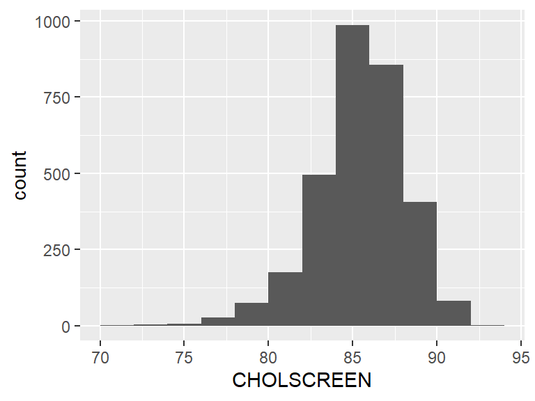

- Note that the following possible outlier values were detected: "70.1", "70.8", "71", "72.2", "73.1", …, "91.7", "91.8", "91.9", "92.4", "93.2" (26 values omitted).

## COLON_SCREEN

| Feature | Result |
| --- | --- |
| Variable type | numeric |
| Number of missing obs. | 78 (2.42 %) |
| Number of unique values | 252 |
| Median | 70.6 |
| 1st and 3rd quartiles | 67.7; 73.7 |
| Min. and max. | 50.1; 83.1 |

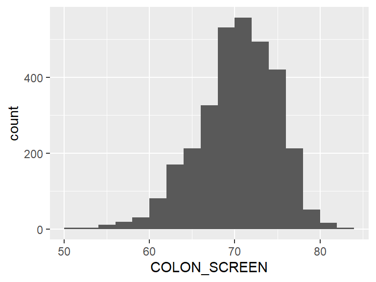

- Note that the following possible outlier values were detected: "50.1", "50.5", "51.9", "52.6", "53.6", …, "81.8", "81.9", "82.1", "83", "83.1" (18 values omitted).

## COPD

| Feature | Result |
| --- | --- |
| Variable type | numeric |
| Number of missing obs. | 78 (2.42 %) |
| Number of unique values | 135 |
| Median | 8.5 |
| 1st and 3rd quartiles | 7; 10 |
| Min. and max. | 3.2; 19.8 |

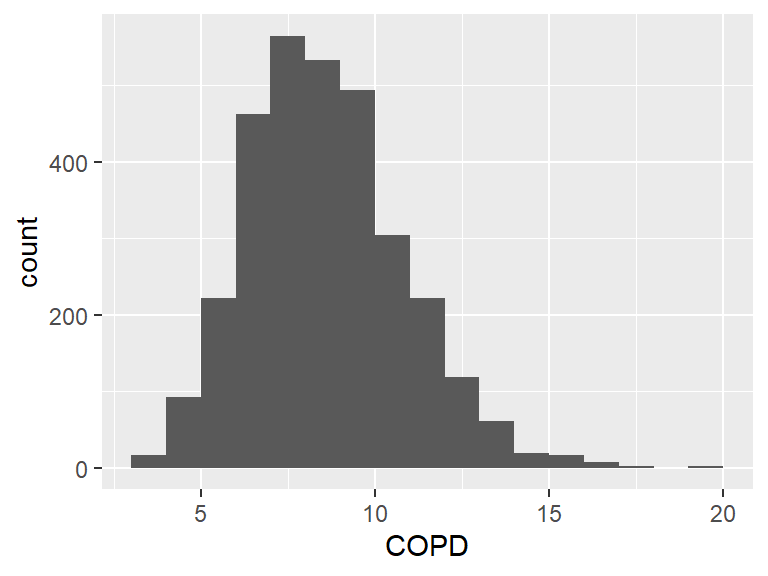

- Note that the following possible outlier values were detected: "3.2", "15.4", "15.5", "15.6", "15.8", …, "16.9", "17.1", "17.4", "19.2", "19.8" (8 values omitted).

## COREM

| Feature | Result |
| --- | --- |
| Variable type | numeric |
| Number of missing obs. | 78 (2.42 %) |
| Number of unique values | 289 |
| Median | 42.3 |
| 1st and 3rd quartiles | 39; 45.6 |
| Min. and max. | 19.2; 60.9 |

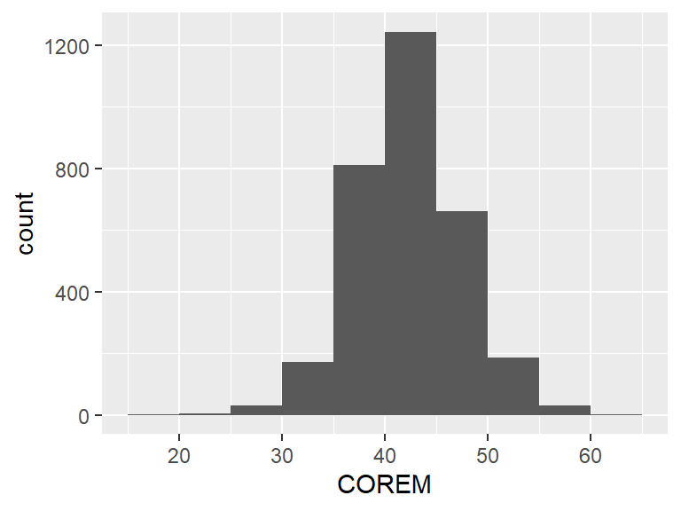

- Note that the following possible outlier values were detected: "19.2", "19.3", "22.9", "23.2", "24.4", …, "58", "58.3", "59.2", "59.3", "60.9" (26 values omitted).

## COREW

| Feature | Result |
| --- | --- |
| Variable type | numeric |
| Number of missing obs. | 78 (2.42 %) |
| Number of unique values | 259 |
| Median | 36.6 |
| 1st and 3rd quartiles | 33.8; 39.6 |
| Min. and max. | 16.3; 53.1 |

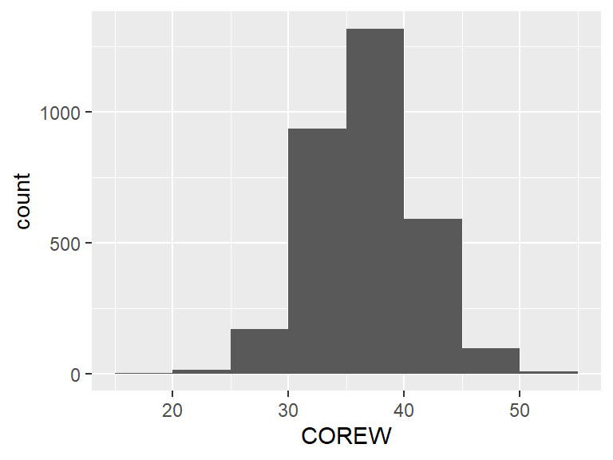

- Note that the following possible outlier values were detected: "16.3", "17.8", "18.6", "21.6", "22", …, "50.6", "52.1", "52.4", "52.9", "53.1" (24 values omitted).

## CSMOKING

| Feature | Result |
| --- | --- |
| Variable type | numeric |
| Number of missing obs. | 78 (2.42 %) |
| Number of unique values | 236 |
| Median | 18.6 |
| 1st and 3rd quartiles | 16.3; 21.4 |
| Min. and max. | 5.2; 41.1 |

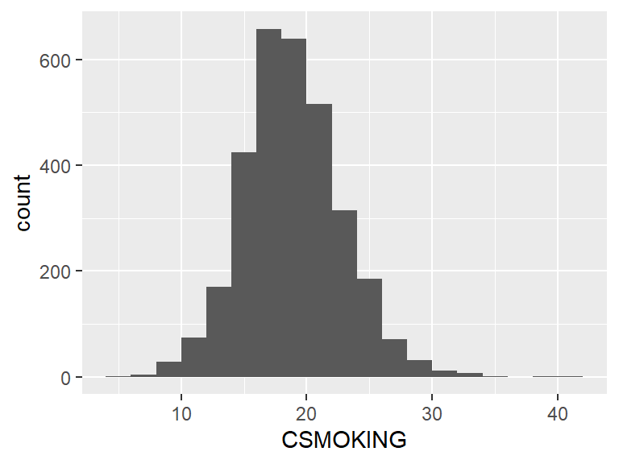

- Note that the following possible outlier values were detected: "5.2", "6.3", "7", "7.9", "8", …, "34.4", "35.7", "39.8", "40.7", "41.1" (31 values omitted).

## DENTAL

| Feature | Result |
| --- | --- |
| Variable type | numeric |
| Number of missing obs. | 78 (2.42 %) |
| Number of unique values | 365 |
| Median | 60.6 |
| 1st and 3rd quartiles | 54.3; 65.4 |
| Min. and max. | 33.6; 80.6 |

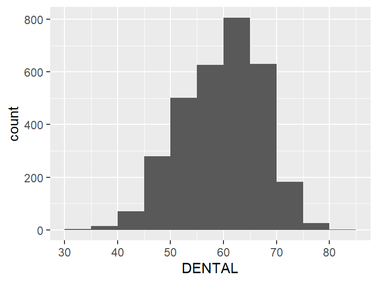

- Note that the following possible outlier values were detected: "74.9", "75", "75.1", "75.2", "75.3", …, "77.7", "77.8", "79.4", "80", "80.6" (10 values omitted).

## DEPRESSION

| Feature | Result |
| --- | --- |
| Variable type | numeric |
| Number of missing obs. | 78 (2.42 %) |
| Number of unique values | 167 |
| Median | 21.1 |
| 1st and 3rd quartiles | 18.8; 23.3 |
| Min. and max. | 10.7; 30.7 |

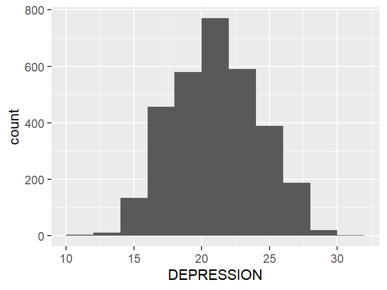

- Note that the following possible outlier values were detected: "10.7", "11.1", "11.5", "30.1", "30.7".

## DIABETES

| Feature | Result |
| --- | --- |
| Variable type | numeric |
| Number of missing obs. | 78 (2.42 %) |
| Number of unique values | 158 |
| Median | 12.4 |
| 1st and 3rd quartiles | 10.9; 14.4 |
| Min. and max. | 6.2; 25.9 |

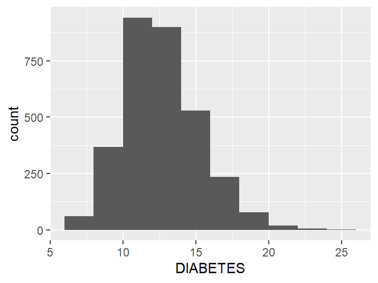

- Note that the following possible outlier values were detected: "6.2", "6.3", "6.4", "6.5", "6.6", …, "22.9", "23.5", "23.6", "25", "25.9" (14 values omitted).

## GHLTH

| Feature | Result |
| --- | --- |
| Variable type | numeric |
| Number of missing obs. | 78 (2.42 %) |
| Number of unique values | 249 |
| Median | 16.9 |
| 1st and 3rd quartiles | 14.1; 20.8 |
| Min. and max. | 7.2; 40.3 |

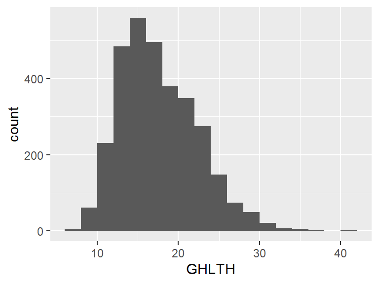

- Note that the following possible outlier values were detected: "7.2", "7.4", "7.9", "8", "8.1", …, "8.4", "8.5", "8.6", "37.5", "40.3" (2 values omitted).

## HIGHCHOL

| Feature | Result |
| --- | --- |
| Variable type | numeric |
| Number of missing obs. | 101 (3.14 %) |
| Number of unique values | 196 |
| Median | 35.5 |
| 1st and 3rd quartiles | 33; 37.7 |
| Min. and max. | 20.6; 45.3 |

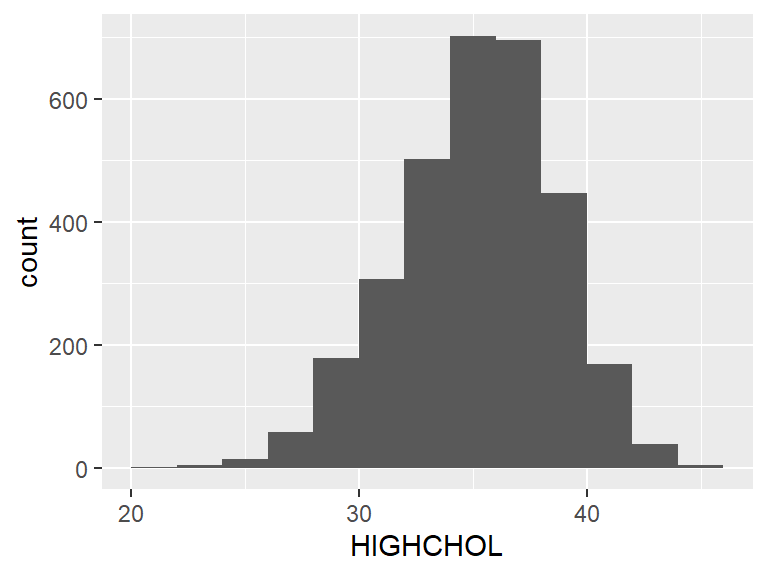

- Note that the following possible outlier values were detected: "20.6", "20.7", "23.4", "23.6", "23.7", …, "44", "44.5", "44.9", "45.2", "45.3" (8 values omitted).

## KIDNEY

| Feature | Result |
| --- | --- |
| Variable type | numeric |
| Number of missing obs. | 78 (2.42 %) |
| Number of unique values | 44 |
| Median | 3.5 |
| 1st and 3rd quartiles | 3.1; 3.9 |
| Min. and max. | 1.9; 6.5 |

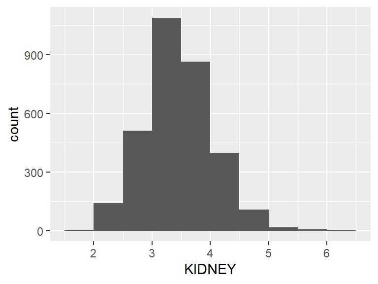

- Note that the following possible outlier values were detected: "1.9", "5.2", "5.3", "5.4", "5.5", …, "5.8", "5.9", "6", "6.1", "6.5" (2 values omitted).

## LPA

| Feature | Result |
| --- | --- |
| Variable type | numeric |
| Number of missing obs. | 78 (2.42 %) |
| Number of unique values | 286 |
| Median | 26.6 |
| 1st and 3rd quartiles | 23.4; 30.6 |
| Min. and max. | 11.8; 47.8 |

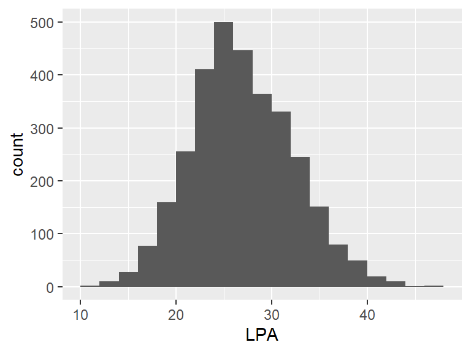

- Note that the following possible outlier values were detected: "11.8", "11.9", "12.1", "12.8", "13.3", …, "15.6", "15.8", "15.9", "47.2", "47.8" (14 values omitted).

## MAMMOUSE

| Feature | Result |
| --- | --- |
| Variable type | numeric |
| Number of missing obs. | 78 (2.42 %) |
| Number of unique values | 222 |
| Median | 70.7 |
| 1st and 3rd quartiles | 67.9; 73.4 |
| Min. and max. | 51.9; 83.5 |

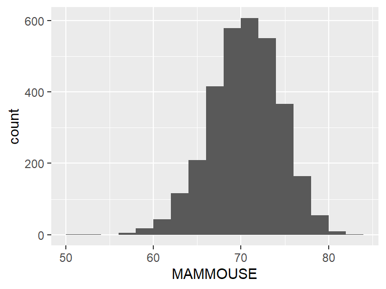

- Note that the following possible outlier values were detected: "51.9", "52.4", "56.6", "56.8", "57.4", …, "58.8", "80.8", "81.9", "82", "83.5" (6 values omitted).

## MHLTH

| Feature | Result |
| --- | --- |
| Variable type | numeric |
| Number of missing obs. | 78 (2.42 %) |
| Number of unique values | 117 |
| Median | 14.7 |
| 1st and 3rd quartiles | 13.1; 16.1 |
| Min. and max. | 8.2; 21.5 |

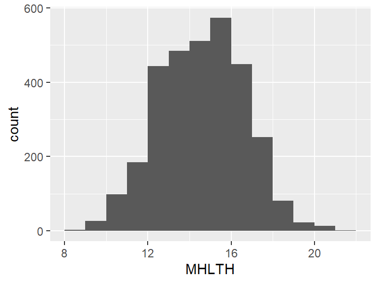

- Note that the following possible outlier values were detected: "19.9", "20", "20.1", "20.2", "20.3", "20.4", "20.5", "20.6", "21", "21.5".

## OBESITY

| Feature | Result |
| --- | --- |
| Variable type | numeric |
| Number of missing obs. | 78 (2.42 %) |
| Number of unique values | 280 |
| Median | 36.5 |
| 1st and 3rd quartiles | 33.3; 39 |
| Min. and max. | 17.1; 52.4 |

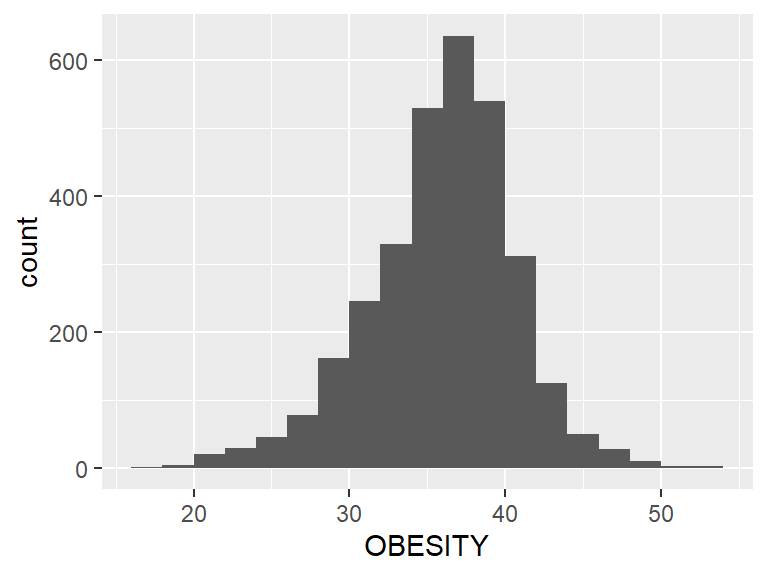

- Note that the following possible outlier values were detected: "17.1", "18.2", "18.8", "19.1", "20", …, "49.7", "50.5", "50.8", "52.2", "52.4" (48 values omitted).

## PHLTH

| Feature | Result |
| --- | --- |
| Variable type | numeric |
| Number of missing obs. | 78 (2.42 %) |
| Number of unique values | 140 |
| Median | 11.8 |
| 1st and 3rd quartiles | 10.3; 13.6 |
| Min. and max. | 5.8; 23.2 |

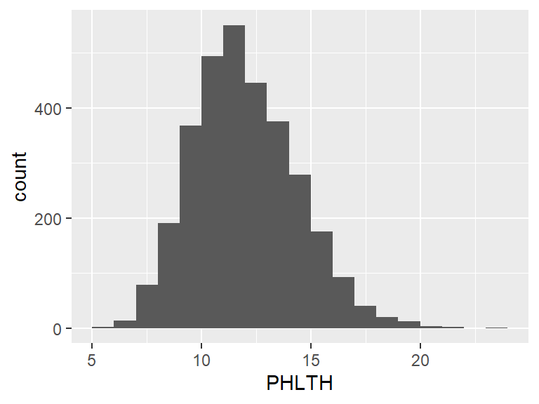

- Note that the following possible outlier values were detected: "5.8", "6", "6.3", "6.4", "6.5", …, "20.8", "21", "21.3", "22", "23.2" (4 values omitted).

## SLEEP

| Feature | Result |
| --- | --- |
| Variable type | numeric |
| Number of missing obs. | 78 (2.42 %) |
| Number of unique values | 199 |
| Median | 33.3 |
| 1st and 3rd quartiles | 30.7; 35.8 |
| Min. and max. | 23.2; 46.4 |

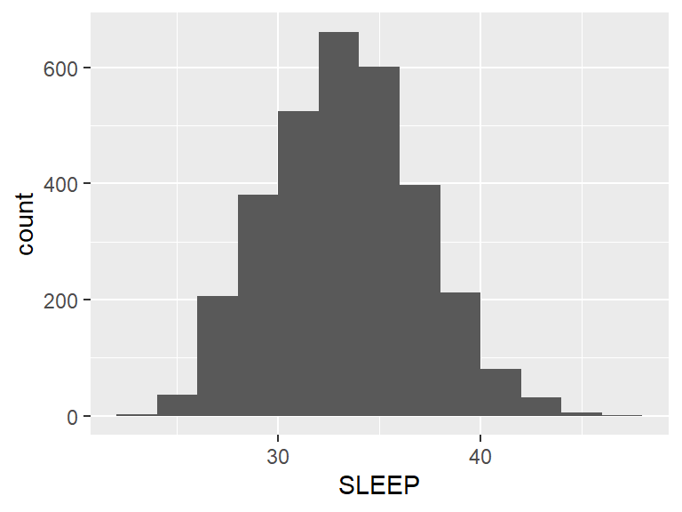

- Note that the following possible outlier values were detected: "43.5", "43.6", "43.9", "44", "44.1", "44.6", "44.9", "45.1", "45.5", "46.4".

## STROKE

| Feature | Result |
| --- | --- |
| Variable type | numeric |
| Number of missing obs. | 78 (2.42 %) |
| Number of unique values | 57 |
| Median | 3.8 |
| 1st and 3rd quartiles | 3.3; 4.4 |
| Min. and max. | 1.7; 8 |

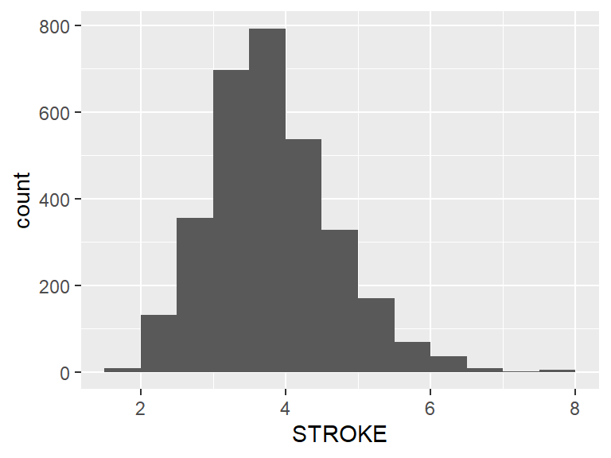

- Note that the following possible outlier values were detected: "1.7", "1.9", "2", "6.5", "6.6", …, "7.2", "7.6", "7.7", "7.8", "8" (3 values omitted).

## TEETHLOST

| Feature | Result |
| --- | --- |
| Variable type | numeric |
| Number of missing obs. | 78 (2.42 %) |
| Number of unique values | 211 |
| Median | 12.6 |
| 1st and 3rd quartiles | 10.4; 15.6 |
| Min. and max. | 3.3; 34.5 |

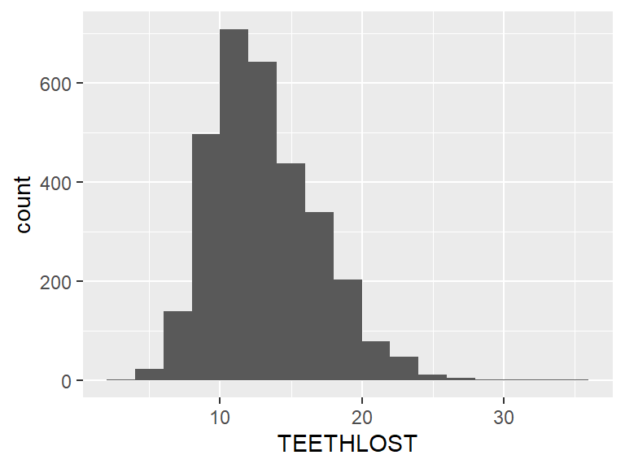

- Note that the following possible outlier values were detected: "3.3", "3.7", "4.3", "4.4", "4.5", …, "28.3", "30.1", "32.9", "34.1", "34.5" (12 values omitted).

## ncrural

- Note that this variable is treated as a factor variable below, as it only takes a few unique values.

| Feature | Result |
| --- | --- |
| Variable type | numeric |
| Number of missing obs. | 0 (0 %) |
| Number of unique values | 3 |
| Mode | “3” |
| Reference category | 1 |

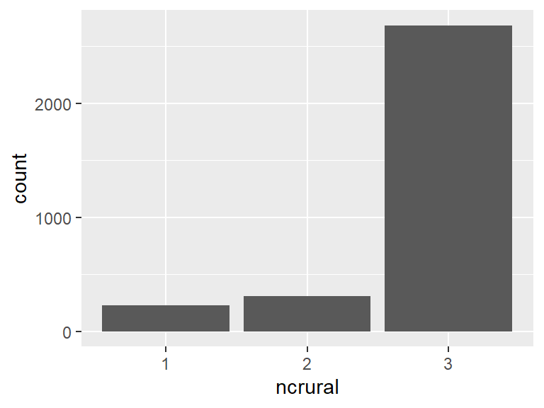

## ncrural_Desc

| Feature | Result |
| --- | --- |
| Variable type | character |
| Number of missing obs. | 0 (0 %) |
| Number of unique values | 3 |
| Mode | “Rural” |

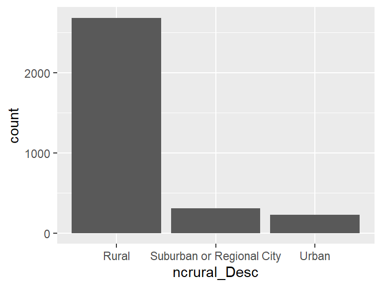

## ncrural_fact

| Feature | Result |
| --- | --- |
| Variable type | factor |
| Number of missing obs. | 0 (0 %) |
| Number of unique values | 3 |
| Mode | “3” |
| Reference category | 1 |

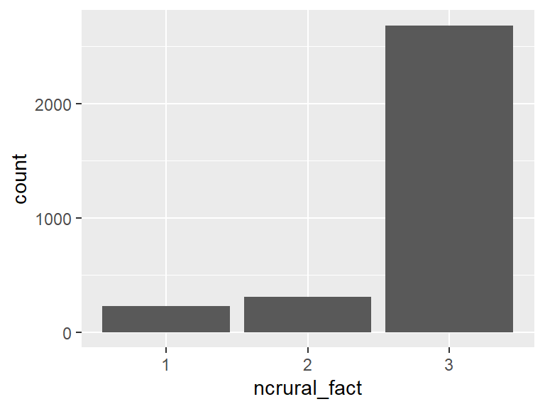

## RUCC_2013

| Feature | Result |
| --- | --- |
| Variable type | numeric |
| Number of missing obs. | 4 (0.12 %) |
| Number of unique values | 9 |
| Median | 6 |
| 1st and 3rd quartiles | 2; 7 |
| Min. and max. | 1; 9 |

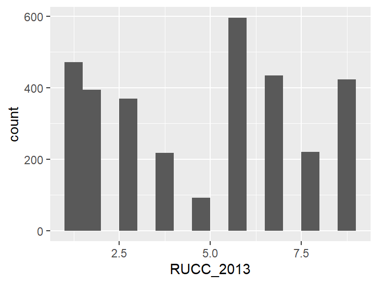

- Note that the following possible outlier values were detected: "9".

## RUCC_Desc

| Feature | Result |
| --- | --- |
| Variable type | factor |
| Number of missing obs. | 4 (0.12 %) |
| Number of unique values | 9 |
| Mode | “Nonmetro - Urban population of 2,500 to 19,999, adjacent to a metro area” |
| Reference category | Metro - Counties in metro areas of 1 million population or more |

[figure not shown]

## RUCC_fact

| Feature | Result |
| --- | --- |
| Variable type | factor |
| Number of missing obs. | 4 (0.12 %) |
| Number of unique values | 9 |
| Mode | “6” |
| Reference category | 1 |

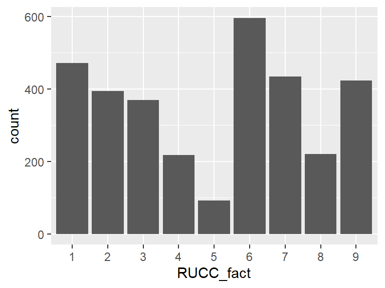

- The following suspected missing value codes enter as regular values: "8", "9".

## UIC_2013

| Feature | Result |
| --- | --- |
| Variable type | numeric |
| Number of missing obs. | 4 (0.12 %) |
| Number of unique values | 12 |
| Median | 5 |
| 1st and 3rd quartiles | 2; 8 |
| Min. and max. | 1; 12 |

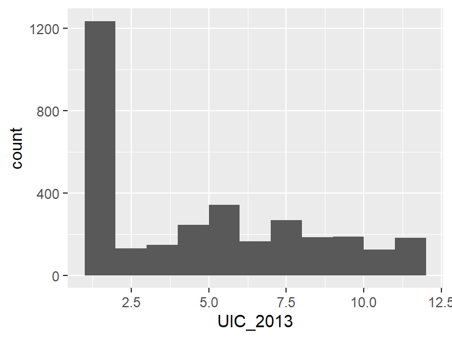

## UIC_Desc

| Feature | Result |
| --- | --- |
| Variable type | factor |
| Number of missing obs. | 4 (0.12 %) |
| Number of unique values | 12 |
| Mode | “Small-in a metro area with fewer than 1 million residents” |
| Reference category | Large-in a metro area with at least 1 million residents or more |

[figure not shown]

## UIC_fact

| Feature | Result |
| --- | --- |
| Variable type | factor |
| Number of missing obs. | 4 (0.12 %) |
| Number of unique values | 12 |
| Mode | “2” |
| Reference category | 1 |

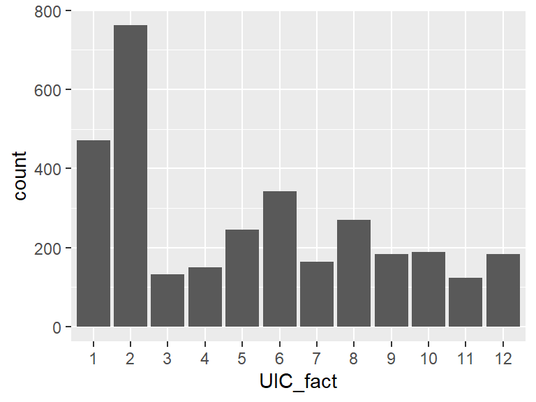

- Note: The variable consists exclusively of numbers and takes a lot of different values. Is it perhaps a misclassified numeric variable?

## PCT_LACCESS_POP15

| Feature | Result |
| --- | --- |
| Variable type | numeric |
| Number of missing obs. | 101 (3.14 %) |
| Number of unique values | 3112 |
| Median | 19.18 |
| 1st and 3rd quartiles | 10.93; 28.83 |
| Min. and max. | 0; 100 |

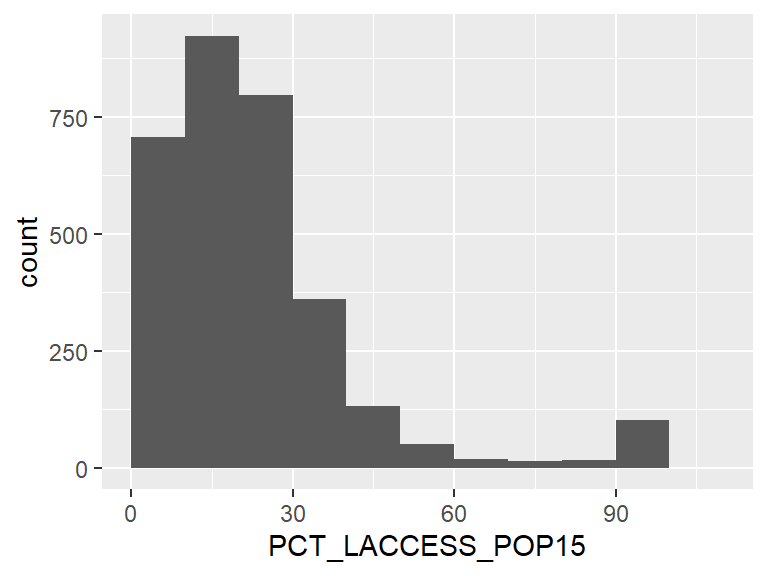

- Note that the following possible outlier values were detected: "68.28", "69.04", "69.45", "69.67", "69.88", …, "100", "100", "100", "100", "100" (128 values omitted).

## GROCPTH16

| Feature | Result |
| --- | --- |
| Variable type | numeric |
| Number of missing obs. | 82 (2.55 %) |
| Number of unique values | 3021 |
| Median | 0.19 |
| 1st and 3rd quartiles | 0.13; 0.28 |
| Min. and max. | 0; 3.27 |

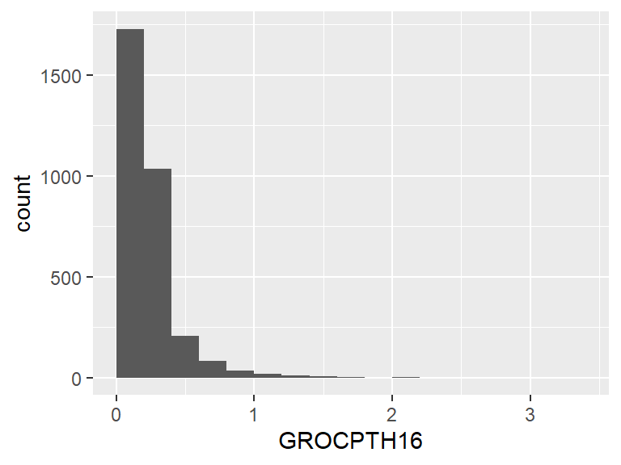

- Note that the following possible outlier values were detected: "0", "0.01", "0.02", "0.04", "0.04", …, "2.01", "2.13", "2.21", "2.54", "3.27" (159 values omitted).

## SUPERCPTH16

| Feature | Result |
| --- | --- |
| Variable type | numeric |
| Number of missing obs. | 82 (2.55 %) |
| Number of unique values | 1781 |
| Median | 0.01 |
| 1st and 3rd quartiles | 0; 0.03 |
| Min. and max. | 0; 0.25 |

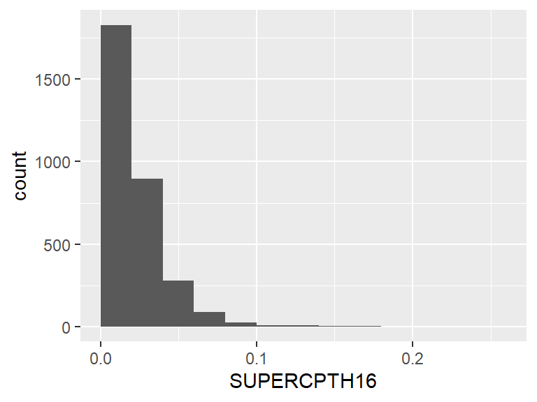

- Note that the following possible outlier values were detected: "0.08", "0.08", "0.08", "0.08", "0.08", …, "0.17", "0.18", "0.19", "0.22", "0.25" (32 values omitted).

## CONVSPTH16

| Feature | Result |
| --- | --- |
| Variable type | numeric |
| Number of missing obs. | 82 (2.55 %) |
| Number of unique values | 3072 |
| Median | 0.54 |
| 1st and 3rd quartiles | 0.4; 0.72 |
| Min. and max. | 0; 3.68 |

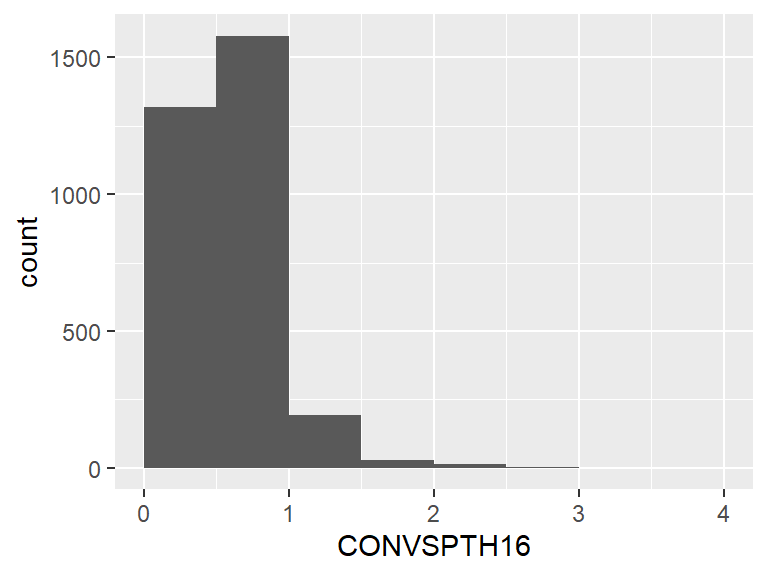

- Note that the following possible outlier values were detected: "0", "0.07", "0.07", "0.1", "0.11", …, "2.54", "2.79", "2.91", "3.43", "3.68" (48 values omitted).

## SNAPSPTH17

| Feature | Result |
| --- | --- |
| Variable type | numeric |
| Number of missing obs. | 106 (3.29 %) |
| Number of unique values | 3103 |
| Median | 0.86 |
| 1st and 3rd quartiles | 0.68; 1.1 |
| Min. and max. | 0.04; 5.9 |

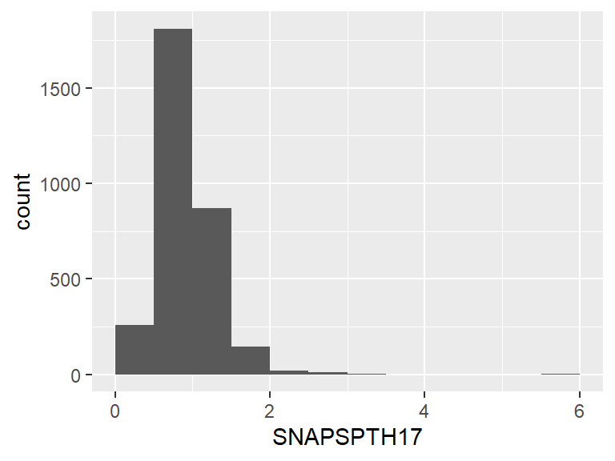

- Note that the following possible outlier values were detected: "0.04", "0.12", "0.14", "0.14", "0.15", …, "2.89", "3.22", "3.31", "5.56", "5.9" (64 values omitted).